# DDS Case Study 2 : Employee Data Analysis

Lijo Jacob

2023-04-14

## Libraries

```r
library(class)
library(e1071)
library(dplyr)
library(RCurl)
library(ggplot2)
library(caret)
library(dplyr)
library(magrittr)
library(tidyverse)
library(reshape2)
library(ggcorrplot)
library(cowplot)
```

## Employee Attrition Analysis

We have 870 observations and 35 features in Employee data

Most of the features are either integers or factors(string & numeric).

First we will find out the features contributing to attrition

Lets find top 3 factors from the set of features

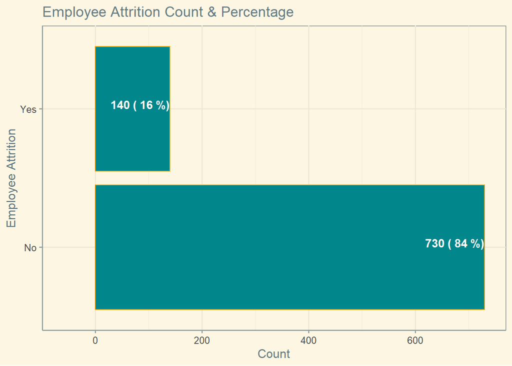

```r
# Read in employee data from AWS S3 location
job_df <- read.table(textConnection(getURL(
  "https://ddsproject1.s3.us-east-2.amazonaws.com/CaseStudy2-data.csv"
)), sep=",", header=TRUE)

#Assigning another data frame
cs2df =job_df

#Ordering the columns so that all numerical features are together
cs2df = cs2df %>%
  select('ID','Attrition','BusinessTravel','DailyRate','Department','EducationField','EmployeeCount',
         'EmployeeNumber','Gender','HourlyRate','JobRole','MaritalStatus','Over18','OverTime',
         'StandardHours','TrainingTimesLastYear','DistanceFromHome','Education','MonthlyRate',
         'PercentSalaryHike','PerformanceRating','YearsAtCompany','YearsInCurrentRole',
         'YearsSinceLastPromotion','YearsWithCurrManager','WorkLifeBalance','JobInvolvement',
         'JobSatisfaction','JobLevel','MonthlyIncome','Age','EnvironmentSatisfaction',
         'NumCompaniesWorked','RelationshipSatisfaction','StockOptionLevel','TotalWorkingYears')

#Employee Attrition Count & Percentage
cs2df %>% group_by(Attrition) %>% summarise(Count=n()) %>%
  mutate(pct=round(prop.table(Count),2) * 100) %>%
  mutate(cntpct=paste(Count, "(",pct,"%)")) %>%
  ggplot(aes(y=Attrition, x=Count)) + geom_bar(stat="identity", fill="turquoise4", color="orange") +
  ggthemes::theme_solarized() +
  geom_text(aes(y=Attrition, x=Count-200, label= cntpct),
            hjust=-0.8, vjust=0, size=4,
            colour="white", fontface="bold",
            angle=360) + labs(title="Employee Attrition Count & Percentage", y="Employee Attrition",x="Count") +
  theme(text = element_text(size = 12))
```

```r
#Assigning another data frame
cs2dfa = cs2df
cs2dfa$Attrition = ifelse(cs2dfa$Attrition == 'Yes',1,0)
cs2dfa$OverTime = ifelse(cs2dfa$OverTime == 'Yes',1,0)
min_max <- function(x) {
  res <- (x - min(x))/(max(x) - min(x))
  return(res)
}
cs2dfa <-  cbind(cs2dfa[,1:16],sapply(cs2dfa[,17:36], min_max))
# Categorical variables to numeric
cs2dfa <- cbind(cs2dfa, model.matrix(~ BusinessTravel - 1, cs2dfa))
cs2dfa <- cbind(cs2dfa, model.matrix(~ Department - 1, cs2dfa))
cs2dfa <- cbind(cs2dfa, model.matrix(~ MaritalStatus - 1, cs2dfa))
cs2dfa <- cbind(cs2dfa, model.matrix(~ JobRole - 1, cs2dfa))

#Using Linear Regression to do a t-test to find the top 3 factors determining Attrition
fit = lm(Attrition~WorkLifeBalance + JobInvolvement + JobSatisfaction +
           OverTime + EnvironmentSatisfaction + NumCompaniesWorked +
           TotalWorkingYears + MaritalStatus, data = cs2dfa)
summary(fit)
```

```
##
## Call:
## lm(formula = Attrition ~ WorkLifeBalance + JobInvolvement + JobSatisfaction +
##     OverTime + EnvironmentSatisfaction + NumCompaniesWorked +
##     TotalWorkingYears + MaritalStatus, data = cs2dfa)
##
## Residuals:
##      Min       1Q   Median       3Q      Max
## -0.59832 -0.20396 -0.08654  0.05098  1.28539
##
## Coefficients:
##                         Estimate Std. Error t value Pr(>|t|)
## (Intercept)              0.42212    0.05716   7.385 3.62e-13 ***
## WorkLifeBalance         -0.12305    0.04730  -2.601  0.00945 **
## JobInvolvement          -0.27260    0.04789  -5.692 1.72e-08 ***
## JobSatisfaction         -0.13685    0.03028  -4.519 7.09e-06 ***
## OverTime                 0.21734    0.02474   8.786  < 2e-16 ***
## EnvironmentSatisfaction -0.09017    0.03072  -2.936  0.00342 **
## NumCompaniesWorked       0.13229    0.04142   3.194  0.00145 **
## TotalWorkingYears       -0.35335    0.06200  -5.699 1.66e-08 ***
## MaritalStatusMarried     0.08091    0.02894   2.796  0.00529 **
## MaritalStatusSingle      0.17465    0.03139   5.565 3.51e-08 ***
## ---
## Signif. codes:  0 '***' 0.001 '**' 0.01 '*' 0.05 '.' 0.1 ' ' 1
##
## Residual standard error: 0.3295 on 860 degrees of freedom
## Multiple R-squared:  0.2051, Adjusted R-squared:  0.1968
## F-statistic: 24.66 on 9 and 860 DF,  p-value: < 2.2e-16
```

```r
confint(fit)
```

```
##                               2.5 %      97.5 %
## (Intercept)              0.30992179  0.53430932
## WorkLifeBalance         -0.21589725 -0.03020852
## JobInvolvement          -0.36658883 -0.17860301
## JobSatisfaction         -0.19628568 -0.07740783
## OverTime                 0.16878818  0.26588866
## EnvironmentSatisfaction -0.15045687 -0.02988345
## NumCompaniesWorked       0.05099203  0.21358000
## TotalWorkingYears       -0.47504754 -0.23165025
## MaritalStatusMarried     0.02410989  0.13770925
## MaritalStatusSingle      0.11305073  0.23625534
```

## Top 3 Factors in Employee Attrition Analysis

After fitting the factors such as Work Life Balance, Job Involvement, Job Satisfaction, Over Time, Environment Satisfaction, Number of Companies Worked, Total Working Years, Marital Status on a linear regression plane, we evaluated the summary using t-test.

Identified the top 3 factors by looking at the t-score and p value(higher the t-value and lower the probability means those features are strong determining factors for Attrition)

Top 3 Factors found from this data set are Over Time, Total Working Years and Job Involvement

```r
#Verifying the Top 3 Factors using Linear Regressing and t-test
fit = lm(Attrition~JobInvolvement + OverTime + TotalWorkingYears, data = cs2dfa)
summary(fit)
```

```
##
## Call:
## lm(formula = Attrition ~ JobInvolvement + OverTime + TotalWorkingYears,
##     data = cs2dfa)
##
## Residuals:
##      Min       1Q   Median       3Q      Max
## -0.55275 -0.19215 -0.09784  0.00305  1.15523
##
## Coefficients:
##                   Estimate Std. Error t value Pr(>|t|)
## (Intercept)        0.34973    0.03656   9.565  < 2e-16 ***
## JobInvolvement    -0.28293    0.04968  -5.696 1.68e-08 ***
## OverTime           0.21092    0.02568   8.213 7.79e-16 ***
## TotalWorkingYears -0.31634    0.06201  -5.101 4.15e-07 ***
## ---
## Signif. codes:  0 '***' 0.001 '**' 0.01 '*' 0.05 '.' 0.1 ' ' 1
##
## Residual standard error: 0.3432 on 866 degrees of freedom
## Multiple R-squared:  0.1317, Adjusted R-squared:  0.1287
## F-statistic:  43.8 on 3 and 866 DF,  p-value: < 2.2e-16
```

```r
confint(fit)
```

```
##                        2.5 %     97.5 %
## (Intercept)        0.2779685  0.4214996
## JobInvolvement    -0.3804321 -0.1854370
## OverTime           0.1605201  0.2613273
## TotalWorkingYears -0.4380562 -0.1946264
```

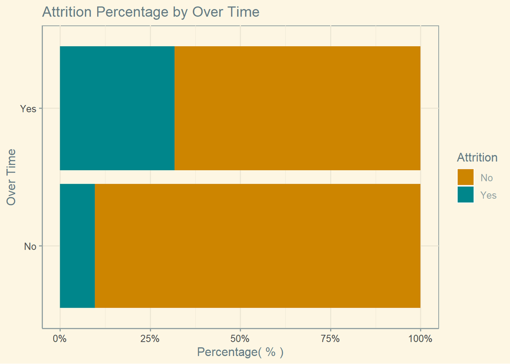

```r
#Analysis on these 3 Top Factors

#Overtime
cs2df %>%
  ggplot(aes(y= OverTime, fill= Attrition )) +   geom_bar(position = "fill") + scale_x_continuous(labels = scales::percent) +
  scale_fill_manual(values = c("orange3", "turquoise4")) + ggthemes::theme_solarized() +
  ggtitle("Attrition Percentage by Over Time") + xlab("Percentage( % )")+ ylab("Over Time") +
  theme(text = element_text(size = 12))
```

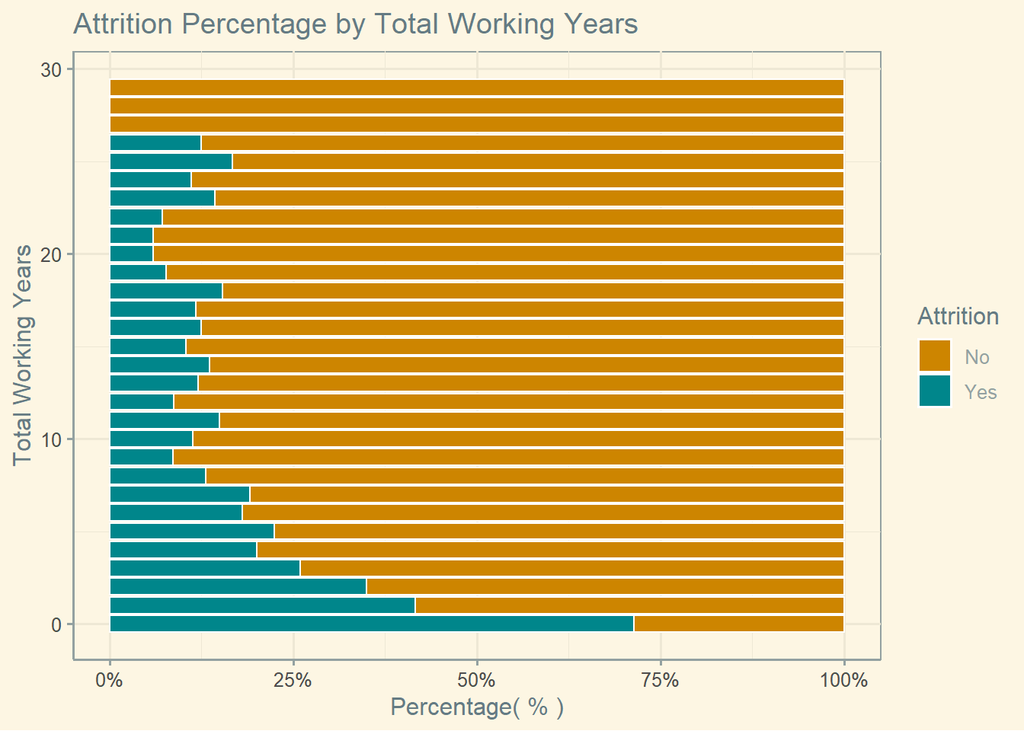

```r
#TotalWorkingYears
cs2df %>% filter(TotalWorkingYears <30) %>%
  ggplot(aes(y= TotalWorkingYears, fill= Attrition )) +   geom_bar(position = "fill", color = "white" ) + scale_x_continuous(labels = scales::percent) +
  scale_fill_manual(values = c("orange3", "turquoise4")) + ggthemes::theme_solarized() +
  ggtitle("Attrition Percentage by Total Working Years") + xlab("Percentage( % )")+ ylab("Total Working Years") +
  theme(text = element_text(size = 12))
```

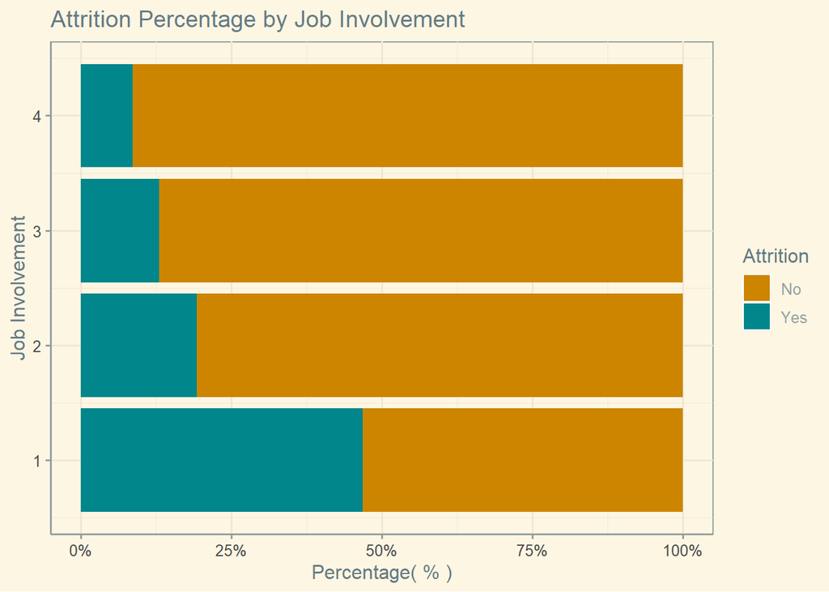

```r
#Job Involvement
cs2df %>%
  ggplot(aes(y= JobInvolvement, fill= Attrition )) +   geom_bar(position = "fill") + scale_x_continuous(labels = scales::percent) +
  scale_fill_manual(values = c("orange3", "turquoise4")) + ggthemes::theme_solarized() +
  ggtitle("Attrition Percentage by Job Involvement") + xlab("Percentage( % )")+ ylab("Job Involvement") +
  theme(text = element_text(size = 12))
```

## Employee Attrition Model

Top 3 factors in Employee data are used to predict Attrition

The dataset is imbalanced on Attrition(Yes-16%; No-84%), so we tried oversampling and under sampling techniques on this data set.

K Nearest Neighbor(KNN) Model performed better compared to Naive Bayes. So we are using KNN for the classification.

Below code is used to find mean accuracy for both KNN and Naive Bayes by iterating them 100 times using various train-test samples from an over sampled data set.

```r
#Build oversampling data frame
cs2dfb = cs2dfa %>% filter(Attrition == 1)
cs2dfc = rbind(cs2dfb,cs2dfb[sample(seq(1,140,1),(730-140),replace = TRUE),])
dim(cs2dfc)
```

```
## [1] 730  54
```

```r
OverSamp = rbind(cs2dfa %>% filter(Attrition == 0), cs2dfc)
dim(OverSamp)
```

```
## [1] 1460   54
```

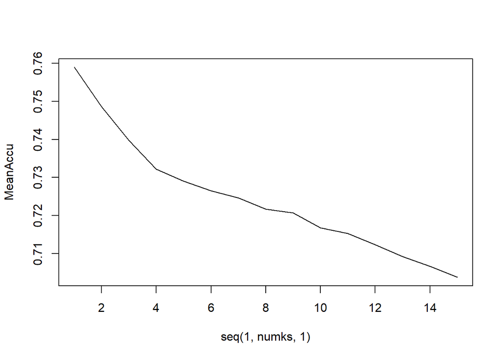

```r
#KNN Model
#Iterate 100 times to find the mean Accuracy, Sensitivity and Specificity
SplitPerc = .7
iterations = 100
numks = 15
masterAccu = matrix(nrow = iterations, ncol = numks)
masterSens = matrix(nrow = iterations, ncol = numks)
masterSpec = matrix(nrow = iterations, ncol = numks)
for(j in 1:iterations)
{
  trainIndices = sample(1:dim(OverSamp)[1], SplitPerc * dim(OverSamp)[1])
  train = OverSamp[trainIndices,]
  test = OverSamp[-trainIndices,]
  for(i in 1:numks)
  {
    classifications = knn(train[,c(14,27,36)],test[,c(14,27,36)],train[,2], prob = TRUE, k=i)
    table(classifications,test[,2])
    CM = confusionMatrix(table(test[,2], classifications))
    masterAccu[j,i] = CM$overall[1]
    masterSens[j,i] = CM$byClass[1]
    masterSpec[j,i] = CM$byClass[2]
  }

}
MeanAccu = colMeans(masterAccu)
MeanSens = colMeans(masterSens)
MeanSpec = colMeans(masterSpec)
plot(seq(1,numks,1),MeanAccu, type = "l")
```

```r
#KNN Mean Accuracy at k=2
MeanAccu[2]
```

```
## [1] 0.7485877
```

```r
#KNN Mean Sensitivity at k=2
MeanSens[2]
```

```
## [1] 0.7920656
```

```r
#KNN Mean Specificity at k=2
MeanSpec[2]
```

```
## [1] 0.7174084
```

```r
#Naive Bayes
#Iterate 100 times to find the mean Accuracy
iterations = 100
SplitPerc = .7
masterAcc1 = matrix(nrow = iterations, ncol = 1)

for(j in 1:iterations)
{
  trainIndices = sample(1:dim(OverSamp)[1], SplitPerc * dim(OverSamp)[1])
  train = OverSamp[trainIndices,]
  test = OverSamp[-trainIndices,]
  #Naive Bayes using over sampling
  model = naiveBayes(train[,c(14,27,36)],train[,2])
  table(predict(model, test[,c(14,27,36)]), test[,2])
  CM = confusionMatrix(table(predict(model, test[,c(14,27,36)]), test[,2]))
  masterAcc1[j,1] = CM$overall[1]
}
MeanAcc1 = colMeans(masterAcc1)
MeanAcc1
```

```
## [1] 0.706082
```

```r
#KNN Classification Model at K=2 on 70:30 Split
trainIndices = sample(1:dim(OverSamp)[1], SplitPerc * dim(OverSamp)[1])
train = OverSamp[trainIndices,]
test = OverSamp[-trainIndices,]
classifications = knn(train[,c(14,27,36)],test[,c(14,27,36)],train[,2], prob = TRUE, k=i)
table(classifications,test[,2])
```

```
##
## classifications   0   1
##               0 140  68
##               1  57 174
```

```r
# Confusion Matrix
CM = confusionMatrix(table(test[,2], classifications))
CM
```

```
## Confusion Matrix and Statistics
##
##    classifications
##       0   1
##   0 140  57
##   1  68 174
##
##                Accuracy : 0.7153
##                  95% CI : (0.6706, 0.757)
##     No Information Rate : 0.5262
##     P-Value [Acc > NIR] : 4.537e-16
##
##                   Kappa : 0.4274
##
##  Mcnemar's Test P-Value : 0.3711
##
##             Sensitivity : 0.6731
##             Specificity : 0.7532
##          Pos Pred Value : 0.7107
##          Neg Pred Value : 0.7190
##              Prevalence : 0.4738
##          Detection Rate : 0.3189
##    Detection Prevalence : 0.4487
##       Balanced Accuracy : 0.7132
##
##        'Positive' Class : 0
##
```

## Employee Monthly Income Analysis

Using 870 observations and 35 features in Employee Dataset, we trying to figure out the features contributing to Monthly Income

We will find top 3 factors from the set of set of features

```r
#Monthly Income Analysis

#Find Min, max, mean and median for monthly income
SummMonthlyInc = job_df %>% summarize(minMonInc = min(MonthlyIncome),
                                      maxMonInc = max(MonthlyIncome),
                                      meanMonInc = mean(MonthlyIncome),
                                      medMonInc = median(MonthlyIncome))
SummMonthlyInc
```

```
##   minMonInc maxMonInc meanMonInc medMonInc
## 1      1081     19999   6390.264    4945.5
```

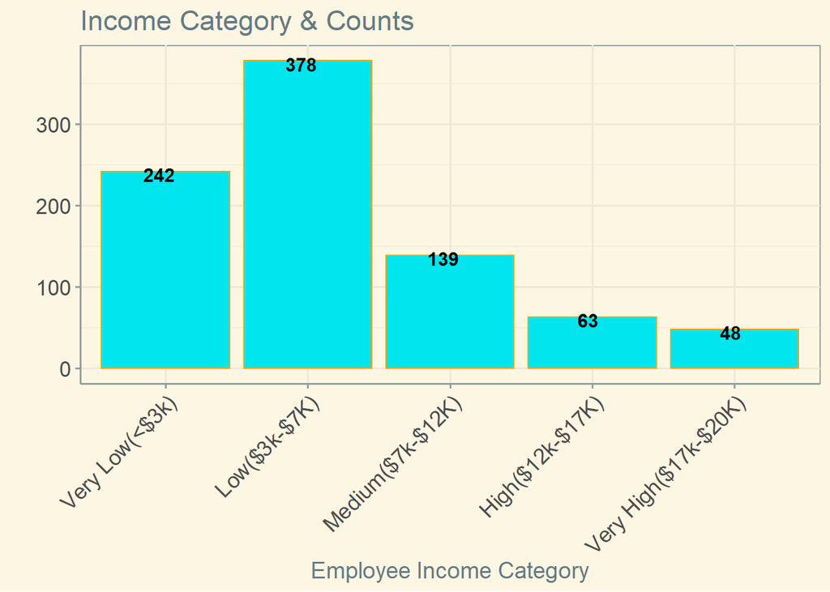

```r
#Creating a plot based on a derived field called Income Category to understand the distribution of data in a better way

job_df %>% mutate(IncomeCategory=cut(job_df$MonthlyIncome,
               breaks=c(1080, 3000, 7000, 12000, 17000, 19999),
               labels=c('Very Low(<$3k)', 'Low($3k-$7K)', 'Medium($7k-$12K)',
                        'High($12k-$17K)', 'Very High($17k-$20K)'))) %>%
  group_by(IncomeCategory)  %>% summarise(Count=n()) %>%
  ggplot(aes(x=IncomeCategory, y= Count)) +
  geom_bar(stat = "identity", color = "orange", fill="turquoise2") +
  ggthemes::theme_solarized() +
  geom_text(aes(x=IncomeCategory, y=Count-30, label= Count),
            hjust=.7, vjust=-1, size=4,
            colour="black", fontface="bold",
            angle=360) +   theme(axis.text.x = element_text(angle = 45, size = 13, hjust=1, vjust=1),
                                 axis.text.y = element_text( size = 13))  +
  labs(title="Income Category & Counts", y="",x="Employee Income Category") +
  theme(text = element_text(size = 14))
```

```r
#Using Linear Regression to do a t-test to find the top 3 factors determining Monthly Income
fit = lm(MonthlyIncome~Department + JobRole + JobLevel + TotalWorkingYears + Age + Education + YearsAtCompany + YearsInCurrentRole + YearsWithCurrManager , data = cs2df)
summary(fit)
```

```
##
## Call:
## lm(formula = MonthlyIncome ~ Department + JobRole + JobLevel +
##     TotalWorkingYears + Age + Education + YearsAtCompany + YearsInCurrentRole +
##     YearsWithCurrManager, data = cs2df)
##
## Residuals:
##     Min      1Q  Median      3Q     Max
## -4050.9  -629.9   -20.5   617.3  4105.7
##
## Coefficients:
##                                  Estimate Std. Error t value Pr(>|t|)
## (Intercept)                      -158.589    524.039  -0.303 0.762246
## DepartmentResearch & Development  199.013    439.996   0.452 0.651164
## DepartmentSales                  -299.967    447.115  -0.671 0.502469
## JobRoleHuman Resources           -124.469    512.418  -0.243 0.808137
## JobRoleLaboratory Technician     -600.290    169.375  -3.544 0.000415 ***
## JobRoleManager                   4210.702    280.763  14.997  < 2e-16 ***
## JobRoleManufacturing Director     150.933    168.332   0.897 0.370164
## JobRoleResearch Director         3998.293    216.941  18.430  < 2e-16 ***
## JobRoleResearch Scientist        -327.680    169.727  -1.931 0.053860 .
## JobRoleSales Executive            454.807    357.601   1.272 0.203781
## JobRoleSales Representative        58.408    388.807   0.150 0.880623
## JobLevel                         2786.687     82.701  33.696  < 2e-16 ***
## TotalWorkingYears                  53.207     10.376   5.128 3.63e-07 ***
## Age                                -1.356      5.579  -0.243 0.807996
## Education                         -25.526     36.726  -0.695 0.487227
## YearsAtCompany                      4.565     12.397   0.368 0.712788
## YearsInCurrentRole                  7.513     16.611   0.452 0.651182
## YearsWithCurrManager              -30.318     16.582  -1.828 0.067850 .
## ---
## Signif. codes:  0 '***' 0.001 '**' 0.01 '*' 0.05 '.' 0.1 ' ' 1
##
## Residual standard error: 1063 on 852 degrees of freedom
## Multiple R-squared:  0.9476, Adjusted R-squared:  0.9466
## F-statistic: 906.5 on 17 and 852 DF,  p-value: < 2.2e-16
```

```r
confint(fit)
```

```
##                                        2.5 %      97.5 %
## (Intercept)                      -1187.14772  869.968826
## DepartmentResearch & Development  -664.59096 1062.617170
## DepartmentSales                  -1177.54289  577.608225
## JobRoleHuman Resources           -1130.21970  881.280847
## JobRoleLaboratory Technician      -932.73214 -267.848222
## JobRoleManager                    3659.63466 4761.769283
## JobRoleManufacturing Director     -179.46031  481.326646
## JobRoleResearch Director          3572.49263 4424.094012
## JobRoleResearch Scientist         -660.81184    5.451376
## JobRoleSales Executive            -247.07486 1156.688108
## JobRoleSales Representative       -704.72428  821.540667
## JobLevel                          2624.36507 2949.009921
## TotalWorkingYears                   32.84090   73.573208
## Age                                -12.30703    9.594517
## Education                          -97.61071   46.558935
## YearsAtCompany                     -19.76745   28.897607
## YearsInCurrentRole                 -25.09024   40.115780
## YearsWithCurrManager               -62.86443    2.229108
```

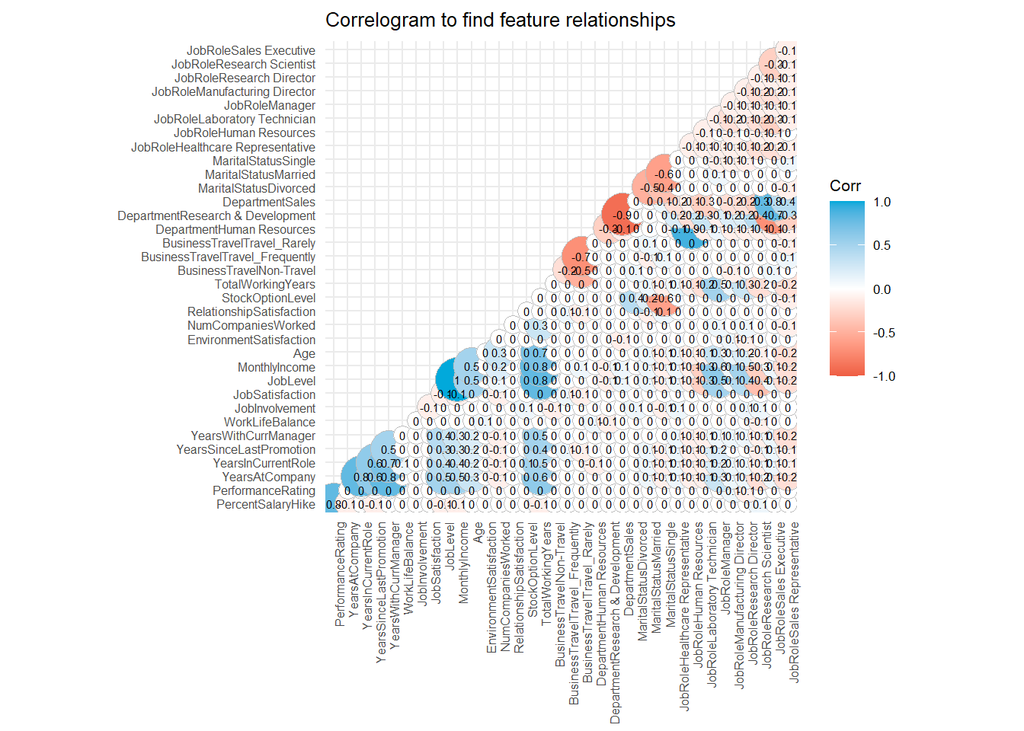

```r
#Correlogram of Employee Features and their relationships
cs2dfnums <- select_if(cs2dfa[,20:54], is.numeric)
corr <- round(cor(cs2dfnums), 1)
ggcorrplot(corr,
           type = "lower",
           lab = TRUE,
           lab_size = 2,
           method="circle",
           colors = c("tomato2", "white", "#01A9DB"),
           title="Correlogram to find feature relationships",
           ggtheme=theme_minimal()) + theme(text = element_text(size = 8)) +
            theme(axis.text.x = element_text( size = 6, angle=90 , hjust=1, vjust=1),
             axis.text.y = element_text( size = 6))
```

## Top 3 Factors in Employee Monthly Income Analysis

After fitting the factors such as Department, Job Role, Job Level, Total Working Years, Age, Education, Years At Company, Years In Current Role and Years With Current Manager on a linear regression plane, we evaluated the summary using t-test.

Identified the top 3 factors by looking at the t score and p value(higher the t-value and lower the probability help us understand that those features are strong determining factors for Monthly Income)

Top 3 Factors found from this data set are Job Level, Total Working Years and Job Role

```r
#Verifying the Top 3 Factors using Linear Regressing and t-test
cs2df =job_df
fit = lm(MonthlyIncome~JobRole + JobLevel + TotalWorkingYears , data = cs2df)
summary(fit)
```

```
##
## Call:
## lm(formula = MonthlyIncome ~ JobRole + JobLevel + TotalWorkingYears,
##     data = cs2df)
##
## Residuals:
##     Min      1Q  Median      3Q     Max
## -3989.9  -631.3    -9.4   616.8  4144.6
##
## Coefficients:
##                               Estimate Std. Error t value Pr(>|t|)
## (Intercept)                   -103.243    203.291  -0.508  0.61168
## JobRoleHuman Resources        -321.962    251.744  -1.279  0.20127
## JobRoleLaboratory Technician  -597.329    168.984  -3.535  0.00043 ***
## JobRoleManager                4002.415    228.696  17.501  < 2e-16 ***
## JobRoleManufacturing Director  137.309    167.212   0.821  0.41178
## JobRoleResearch Director      3993.674    214.342  18.632  < 2e-16 ***
## JobRoleResearch Scientist     -324.522    169.387  -1.916  0.05572 .
## JobRoleSales Executive         -66.048    144.221  -0.458  0.64709
## JobRoleSales Representative   -410.303    211.660  -1.939  0.05289 .
## JobLevel                      2795.329     81.784  34.179  < 2e-16 ***
## TotalWorkingYears               47.998      7.951   6.037 2.34e-09 ***
## ---
## Signif. codes:  0 '***' 0.001 '**' 0.01 '*' 0.05 '.' 0.1 ' ' 1
##
## Residual standard error: 1063 on 859 degrees of freedom
## Multiple R-squared:  0.9472, Adjusted R-squared:  0.9466
## F-statistic:  1541 on 10 and 859 DF,  p-value: < 2.2e-16
```

```r
confint(fit)
```

```
##                                    2.5 %      97.5 %
## (Intercept)                   -502.24771  295.761403
## JobRoleHuman Resources        -816.06631  172.142756
## JobRoleLaboratory Technician  -928.99941 -265.657829
## JobRoleManager                3553.54656 4451.282832
## JobRoleManufacturing Director -190.88231  465.499914
## JobRoleResearch Director      3572.97865 4414.368490
## JobRoleResearch Scientist     -656.98310    7.939995
## JobRoleSales Executive        -349.11412  217.017774
## JobRoleSales Representative   -825.73453    5.128058
## JobLevel                      2634.80874 2955.848371
## TotalWorkingYears               32.39264   63.603616
```

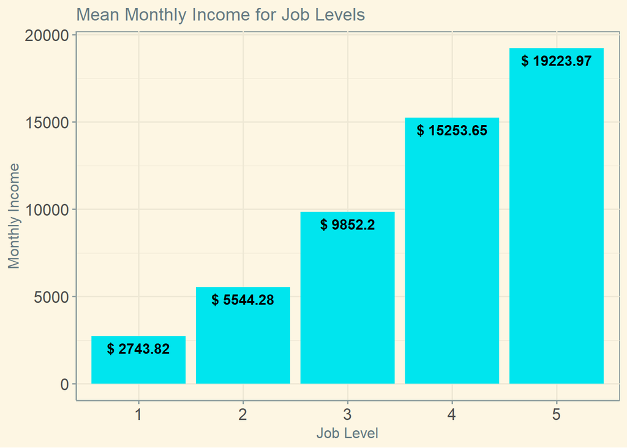

```r
#Analysis on these 3 Top Factors

#Mean Monthly Income for Job Levels
cs2df %>% group_by(JobLevel) %>%
  summarize(meanMonInc = mean(MonthlyIncome)) %>%
  mutate(meanwdol=paste("$",round(meanMonInc,2))) %>%
  ggplot(aes(x= as.factor(JobLevel)  , y= meanMonInc )) +
  geom_bar(stat = "identity", fill="turquoise2")  +
  ggthemes::theme_solarized() +
  geom_text(aes(x=JobLevel, y=meanMonInc-1600, label= meanwdol),
            hjust=.5, vjust=-1, size=4,
            colour="black", fontface="bold",
            angle=360) +   theme(axis.text.x = element_text( size = 13),
                                   axis.text.y = element_text( size = 13)) +
  ggtitle("Mean Monthly Income for Job Levels") +
  xlab("Job Level")+ ylab("Monthly Income") +
  theme(text = element_text(size = 12))
```

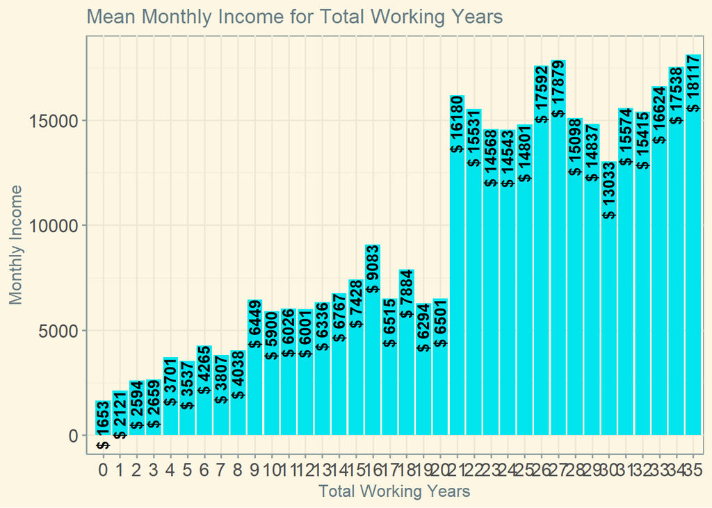

```r
#Mean Monthly Income for Total Working Years
cs2df %>% filter(TotalWorkingYears <36) %>%
  group_by(TotalWorkingYears) %>%
  summarize(meanMonInc = mean(MonthlyIncome)) %>%
  mutate(meanwdol=paste("$",round(meanMonInc,0))) %>%
  ggplot(aes(x= as.factor(TotalWorkingYears)  , y= meanMonInc )) +
  geom_bar(stat = "identity", fill="turquoise2") +
  ggthemes::theme_solarized() +
  geom_text(aes(x=TotalWorkingYears, y=meanMonInc, label= meanwdol),
            hjust=1, vjust=1.8, size=4,
            colour="black", fontface="bold",
            angle=90) +
  theme(axis.text.x = element_text( size = 13),
        axis.text.y = element_text( size = 13)) +
  ggtitle("Mean Monthly Income for Total Working Years") +
  xlab("Total Working Years")+ ylab("Monthly Income") +
  theme(text = element_text(size = 12))
```

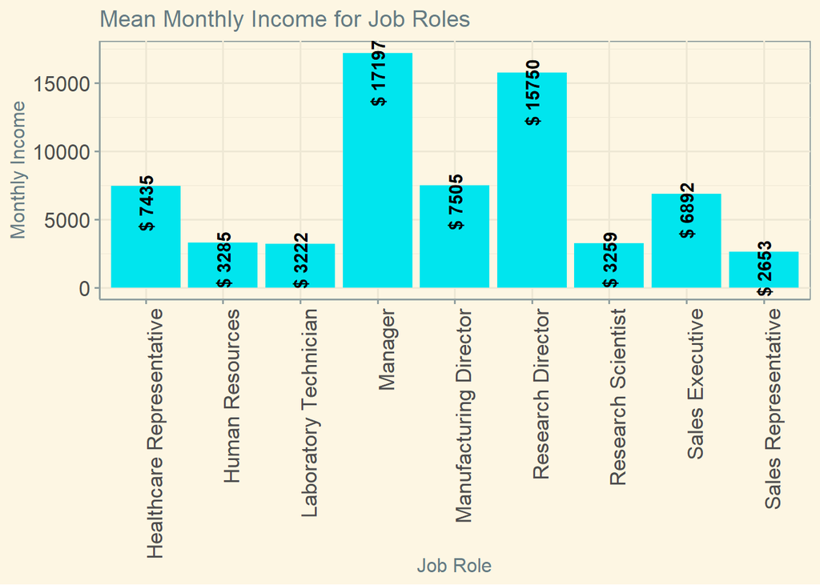

```r
#Mean Monthly Income for Job Roles
cs2df %>% group_by(JobRole) %>%
  summarize(meanMonInc = mean(MonthlyIncome)) %>%
  mutate(meanwdol=paste("$",round(meanMonInc,0))) %>%
  ggplot(aes(x= JobRole  , y= meanMonInc )) +
  geom_bar(stat = "identity", fill="turquoise2") +
  ggthemes::theme_solarized() +
  geom_text(aes(x=JobRole, y=meanMonInc, label= meanwdol),
            hjust=.8, vjust=.5, size=4,
            colour="black", fontface="bold",
            angle=90) +
  theme(axis.text.x = element_text( size = 13, angle=90 , hjust=1, vjust=1),
        axis.text.y = element_text( size = 13)) +
  ggtitle("Mean Monthly Income for Job Roles") +
  xlab("Job Role")+ ylab("Monthly Income") +
  theme(text = element_text(size = 12))
```

## Employee Monthly Income Model

Top 3 factors in Employee data are used to predict Monthly Income

Linear Regression Model is used to predict the values

```r
# Fit  the model using top 3 factors
fit = lm(MonthlyIncome~JobRole + JobLevel + TotalWorkingYears , data = cs2df)
summary(fit)
```

```
##
## Call:
## lm(formula = MonthlyIncome ~ JobRole + JobLevel + TotalWorkingYears,
##     data = cs2df)
##
## Residuals:
##     Min      1Q  Median      3Q     Max
## -3989.9  -631.3    -9.4   616.8  4144.6
##
## Coefficients:
##                               Estimate Std. Error t value Pr(>|t|)
## (Intercept)                   -103.243    203.291  -0.508  0.61168
## JobRoleHuman Resources        -321.962    251.744  -1.279  0.20127
## JobRoleLaboratory Technician  -597.329    168.984  -3.535  0.00043 ***
## JobRoleManager                4002.415    228.696  17.501  < 2e-16 ***
## JobRoleManufacturing Director  137.309    167.212   0.821  0.41178
## JobRoleResearch Director      3993.674    214.342  18.632  < 2e-16 ***
## JobRoleResearch Scientist     -324.522    169.387  -1.916  0.05572 .
## JobRoleSales Executive         -66.048    144.221  -0.458  0.64709
## JobRoleSales Representative   -410.303    211.660  -1.939  0.05289 .
## JobLevel                      2795.329     81.784  34.179  < 2e-16 ***
## TotalWorkingYears               47.998      7.951   6.037 2.34e-09 ***
## ---
## Signif. codes:  0 '***' 0.001 '**' 0.01 '*' 0.05 '.' 0.1 ' ' 1
##
## Residual standard error: 1063 on 859 degrees of freedom
## Multiple R-squared:  0.9472, Adjusted R-squared:  0.9466
## F-statistic:  1541 on 10 and 859 DF,  p-value: < 2.2e-16
```

```r
confint(fit)
```

```
##                                    2.5 %      97.5 %
## (Intercept)                   -502.24771  295.761403
## JobRoleHuman Resources        -816.06631  172.142756
## JobRoleLaboratory Technician  -928.99941 -265.657829
## JobRoleManager                3553.54656 4451.282832
## JobRoleManufacturing Director -190.88231  465.499914
## JobRoleResearch Director      3572.97865 4414.368490
## JobRoleResearch Scientist     -656.98310    7.939995
## JobRoleSales Executive        -349.11412  217.017774
## JobRoleSales Representative   -825.73453    5.128058
## JobLevel                      2634.80874 2955.848371
## TotalWorkingYears               32.39264   63.603616
```

```r
# predict the value of monthly Income
Model1_Preds = predict(fit)

cs2df$predMonInc = Model1_Preds

# find RMSE (Root Mean Squared Error)/MSPE
Model1MSPE = mean((cs2df$MonthlyIncome - cs2df$predMonInc)^2)
sqrt(Model1MSPE)
```

```
## [1] 1056.017
```

## Job Role related Trends

Using Job Role find some interesting trend

For various job roles, we looked at number of years employee worked in a company. The evidence suggest that most of the employees are leaving the company within first 10 years with exceptions to the Job Roles such as ‘Manager’ and ‘Research Director’

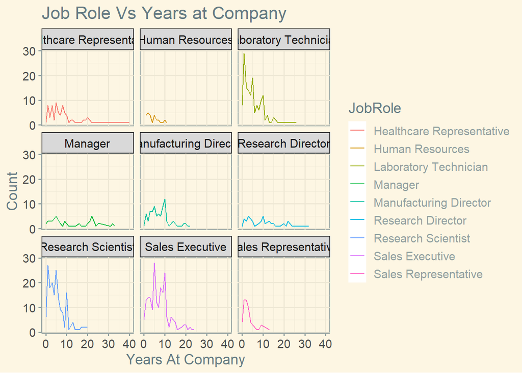

```r
#Job Role Vs Years at Company
job_df %>% group_by(JobRole, YearsAtCompany)  %>%
  ggplot2::ggplot(aes(x=YearsAtCompany, color=JobRole)) +
  ggthemes::theme_solarized() +
  geom_line(stat = "count", linetype = "solid")+
  facet_wrap(~JobRole) +
  labs(title="Job Role Vs Years at Company", y="Count",x="Years At Company") +
  theme(text = element_text(size = 14))
```

## Other related Trends

How Attrition is related to other factors such as Business Travel, Stock Option Level, Job satisfaction and Work life balance

Evidence suggests that

- Employees who travel frequently as part of their job are likely to leave the company more often
- Employees who have no stock options tend to leave the company more often
- Other factors such as low job satisfaction and low work life balance force employees to leave the company

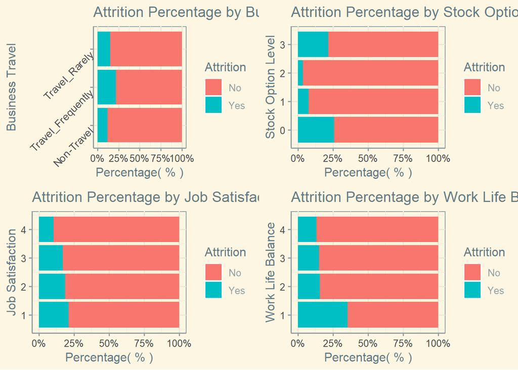

```r
#Other Trends
#Employees who travel frequently as part of job are leaving the company more often
BizTrAttr <- cs2df %>%
  ggplot2::ggplot(aes(y=BusinessTravel, fill = Attrition)) +
  geom_bar(position = "fill") +
  scale_x_continuous(labels = scales::percent) +
  ggthemes::theme_solarized() +
  ggtitle("Attrition Percentage by Business Travel") +
  xlab("Percentage( % )")+
  ylab("Business Travel") +
  theme(axis.text.y = element_text( size = 10, angle=45 , hjust=1, vjust=1)) +
  theme(text = element_text(size = 12))
#Employees who have no stock options tend to  leave the company more often
StoOptLvlAttr <- cs2df %>%
  ggplot2::ggplot(aes(y=StockOptionLevel, fill = Attrition)) +
  geom_bar(position = "fill") +
  scale_x_continuous(labels = scales::percent) +
  ggthemes::theme_solarized() +
  ggtitle("Attrition Percentage by Stock Option Level") +
  xlab("Percentage( % )")+
  ylab("Stock Option Level") +
  theme(text = element_text(size = 12))
#Employees who have less job satisfaction tend to  leave the company more often
JobSatAttr <- cs2df %>%
  ggplot2::ggplot(aes(y=JobSatisfaction, fill = Attrition)) +
  geom_bar(position = "fill") +
  scale_x_continuous(labels = scales::percent) +
  ggthemes::theme_solarized() +
  ggtitle("Attrition Percentage by Job Satisfaction") +
  xlab("Percentage( % )")+
  ylab("Job Satisfaction") +
  theme(text = element_text(size = 12))
#Employees who have less work life balance tend to  leave the company more often
WrkLifBalAttr <- cs2df %>% ggplot2::ggplot(aes(y=WorkLifeBalance, fill = Attrition)) +
  geom_bar(position = "fill") +
  scale_x_continuous(labels = scales::percent) +
  ggthemes::theme_solarized() +
  ggtitle("Attrition Percentage by Work Life Balance") +
  xlab("Percentage( % )")+
  ylab("Work Life Balance") +
  theme(text = element_text(size = 12))

plot_grid(BizTrAttr, StoOptLvlAttr, JobSatAttr, WrkLifBalAttr, align="h", nrow=2, ncol=2)
```

## Recommendations

To retain employees, Company should

- Provide required compensation to employees who do over time or travel frequently
- Provide basic stock option level(1)
- Figure out the more common issues related to low job involvement and work life balance and find solutions
- Pay scale and promotions for employees below the age of 35 should be reviewed/revised
- Newly joined(< 1 year) employees should be provided with perks, recognition and rewards

## Summary

As per our analysis,

- There are multiple factors related to Attrition and top ones are Over Time, Job Involvement and Total working years
- Top factors driving monthly income are Job level, Job Role and Total working years
- For most of the job roles, employees tend to leave the company within 10 years for their service at the company
- Frito Lay to consider one or more of the recommendations